# Naive Bayes Assignment - Fake News Classification

Audrya Kerenhappukh - Author

Ryan Kokke - Reviewer

04 October, 2021

## Business Understanding

Develop a machine learning program to identify when an article might be fake news

## Import Document and Data Understanding

Because text could be really long we’re trying to reduce the file size by making a new variable called ‘author.title’

```r
rawDF$author.title <- paste(rawDF$author, rawDF$title)

cbind(colnames(rawDF))
```

```
##      [,1]
## [1,] "id"
## [2,] "title"
## [3,] "author"
## [4,] "text"
## [5,] "label"
## [6,] "author.title"
```

```r
# Create a new data set with only two variables: 'label' and 'author.title'
cleanDF <- rawDF[c(5,6)]
```

The labels in the dataset are still numerical, we would want to factor them into “unreliable” and “reliable”

```r
cleanDF$label <- factor(cleanDF$label, levels = c(1,0), labels = c("unreliable", "reliable")) %>% relevel("reliable")
```

Visually inspect the data by creating worldclouds

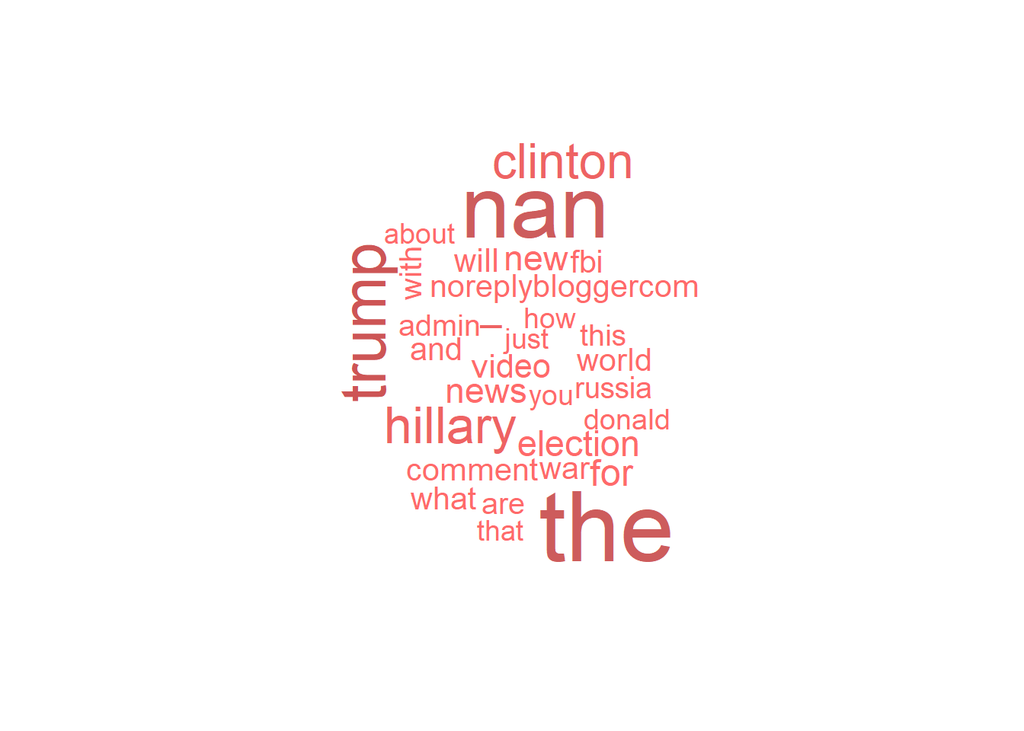

```r
unreliable <- cleanDF %>%
  filter(label == "unreliable")
reliable <- cleanDF %>%
  filter(label == "reliable")

wordcloud(unreliable$author.title, max.words = 30, scale = c(4, 0.8), colors= c("indianred1","indianred2","indianred3","indianred"))
```

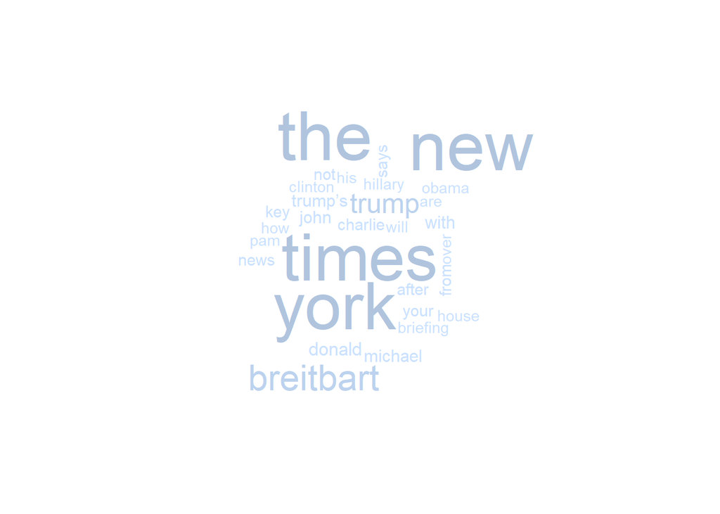

```r
wordcloud(reliable$author.title, max.words = 30, scale = c(4, 0.8), colors= c("lightsteelblue1","lightsteelblue2","lightsteelblue3","lightsteelblue"))
```

## Preparation

### Create corpus

First we need to create a corpus, which refers to a collection of text documents. In our case each is considered a text document

#### Creating corpus for Training data

```r
rawCorpus <- Corpus(VectorSource(cleanDF$author.title))
```

```r
cleanCorpus <- rawCorpus %>% tm_map(tolower) %>% tm_map(removeNumbers)
cleanCorpus <- cleanCorpus %>% tm_map(tolower) %>% tm_map(removeWords, stopwords()) %>% tm_map(removePunctuation)
```

```r
cleanCorpus <- cleanCorpus %>% tm_map(stripWhitespace)
```

See the difference between Raw vs Clean Corpus

```r
tibble(Raw = rawCorpus$content[1:2], Clean = cleanCorpus$content[1:2])
```

| Raw | Clean |
| --- | --- |
| Darrell Lucus House Dem Aide: We Didn’t Even See Comey’s Letter Until Jason Chaffetz Tweeted It | darrell lucus house dem aide didn’t even see comey’s letter jason chaffetz tweeted |
| Daniel J. Flynn FLYNN: Hillary Clinton, Big Woman on Campus - Breitbart | daniel j flynn flynn hillary clinton big woman campus breitbart |

```r
cleanDTM <- cleanCorpus %>% DocumentTermMatrix
inspect(cleanDTM)
```

```
## <<DocumentTermMatrix (documents: 20127, terms: 29710)>>
## Non-/sparse entries: 211027/597762143
## Sparsity           : 100%
## Maximal term length: 62
## Weighting          : term frequency (tf)
## Sample             :
##        Terms
## Docs    breitbart clinton donald hillary nan new news times trump york
##   1129          0       0      0       0   0   0    0     0     0    0
##   15718         0       0      0       0   0   0    0     0     0    0
##   16279         0       0      0       0   0   2    0     0     0    2
##   17905         0       0      0       0   0   0    4     0     0    0
##   18616         0       0      0       0   0   0    0     0     0    0
##   19304         0       0      0       0   0   0    0     0     0    0
##   19568         0       0      0       0   0   0    0     0     0    0
##   3301          0       0      0       0   0   0    0     0     0    0
##   4029          0       0      0       0   0   0    0     0     0    0
##   9532          0       0      0       0   0   0    0     0     0    0
```

Before we can start modelling, it is important to split the data sets into train and test sets. We are using 90% of datasets for training, and 10% for test.

```r
set.seed(1234)
trainIndex <- createDataPartition(cleanDF$label, p = .9,
                                  list = FALSE,
                                  times = 1)
head(trainIndex)
```

```
##      Resample1
## [1,]         1
## [2,]         2
## [3,]         3
## [4,]         4
## [5,]         7
## [6,]        10
```

```r
# Apply split indices to DF
trainDF <- cleanDF[trainIndex, ]
testDF <- cleanDF[-trainIndex, ]

# Apply split indices to Corpus
trainCorpus <- cleanCorpus[trainIndex]
testCorpus <- cleanCorpus[-trainIndex]

# Apply split indices to DTM
trainDTM <- cleanDTM[trainIndex, ]
testDTM <- cleanDTM[-trainIndex, ]
```

### Eliminating Words with lower frequencies

```r
freqwords <- cleanDTM %>% findFreqTerms(1000)
trainDTM <- DocumentTermMatrix(trainCorpus, list(dictionary = freqwords))
testDTM <- DocumentTermMatrix(testCorpus, list(dictionary = freqwords))

inspect(trainDTM)
```

```
## <<DocumentTermMatrix (documents: 18115, terms: 8)>>
## Non-/sparse entries: 25903/119017
## Sparsity           : 82%
## Maximal term length: 9
## Weighting          : term frequency (tf)
## Sample             :
##        Terms
## Docs    breitbart clinton hillary nan new times trump york
##   10147         0       0       0   0   3     3     0    3
##   10240         0       0       0   0   3     2     0    3
##   11614         0       1       1   0   2     1     0    2
##   13115         0       1       1   0   2     1     1    1
##   15972         0       1       1   0   2     1     1    1
##   16962         0       0       0   0   2     3     0    2
##   589           0       0       0   1   2     2     0    2
##   959           0       1       1   0   2     1     1    1
##   9704          0       1       1   0   2     1     1    2
##   9745          0       1       1   0   2     1     1    1
```

```r
inspect(testDTM)
```

```
## <<DocumentTermMatrix (documents: 2012, terms: 8)>>
## Non-/sparse entries: 2933/13163
## Sparsity           : 82%
## Maximal term length: 9
## Weighting          : term frequency (tf)
## Sample             :
##      Terms
## Docs  breitbart clinton hillary nan new times trump york
##   117         0       1       1   0   1     1     1    1
##   277         0       0       0   0   2     2     0    2
##   556         0       1       1   0   2     1     1    2
##   557         0       1       1   0   1     1     1    1
##   587         0       1       1   0   1     1     1    1
##   673         0       0       0   0   3     2     0    2
##   779         0       0       0   0   2     2     0    2
##   87          0       0       0   0   2     2     0    2
##   896         0       0       0   0   2     2     0    2
##   905         0       1       1   0   1     1     1    1
```

Another issue is that the Naive Bayes classifier is typically trained on categorical features. We now have numerical matrix with word counts. We will transform the counts into a factor that simply indicates whether the word appears in the document or not. We’ll first build our own function for this and then apply it to each column in the DTM.

```r
convert_counts <- function(x) {
  x <- ifelse(x > 0, 1, 0) %>%
    factor(levels = c(0,1), labels = c("No", "Yes"))
}

nColsDTM <- dim(trainDTM)[2]
trainDTM <- apply(trainDTM, MARGIN = 2, convert_counts)
testDTM <- apply(testDTM, MARGIN = 2, convert_counts)

head(trainDTM)
```

```
##     Terms
## Docs breitbart clinton hillary nan   new   times trump york
##    1 "No"      "No"    "No"    "No"  "No"  "No"  "No"  "No"
##    2 "Yes"     "Yes"   "Yes"   "No"  "No"  "No"  "No"  "No"
##    3 "No"      "No"    "No"    "No"  "No"  "No"  "No"  "No"
##    4 "No"      "No"    "No"    "No"  "No"  "No"  "No"  "No"
##    5 "No"      "No"    "No"    "Yes" "No"  "No"  "No"  "No"
##    6 "No"      "No"    "No"    "No"  "Yes" "Yes" "Yes" "Yes"
```

## Modeling and Evaluation

Create the model

```r
nbayesModel <-  naiveBayes(trainDTM, trainDF$label, laplace = 1)
```

```r
predVec <- predict(nbayesModel, testDTM)
```

```r
cm <- confusionMatrix(predVec, testDF$label, positive = "unreliable", dnn = c("Prediction", "True"))

cm
```

```
## Confusion Matrix and Statistics
##
##             True
## Prediction   reliable unreliable
##   reliable        879         32
##   unreliable      159        942
##
##                Accuracy : 0.9051
##                  95% CI : (0.8914, 0.9175)
##     No Information Rate : 0.5159
##     P-Value [Acc > NIR] : < 2.2e-16
##
##                   Kappa : 0.8107
##
##  Mcnemar's Test P-Value : < 2.2e-16
##
##             Sensitivity : 0.9671
##             Specificity : 0.8468
##          Pos Pred Value : 0.8556
##          Neg Pred Value : 0.9649
##              Prevalence : 0.4841
##          Detection Rate : 0.4682
##    Detection Prevalence : 0.5472
##       Balanced Accuracy : 0.9070
##
##        'Positive' Class : unreliable
##
```

## Visualization of Confusion Matrix

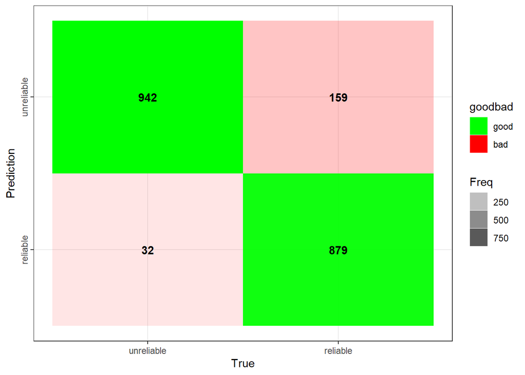

```r
table <- as.data.frame(cm$table)

plotTable <- table %>%
  mutate(goodbad = ifelse(table$Prediction == table$True, "good", "bad")) %>%
  group_by(True) %>%
  mutate(prop = Freq/sum(Freq))

ggplot(data = plotTable, mapping = aes(x = True, y = Prediction, fill = goodbad, alpha = Freq)) +
  geom_tile() +
  geom_text(aes(label = Freq), vjust = .5, fontface  = "bold", alpha = 1) +
  scale_fill_manual(values = c(good = "green", bad = "red")) +
  theme_bw() +
  xlim(rev(levels(table$True))) +
  theme(axis.text.y = element_text(angle=90, hjust=0.5))
```